# Anatomy of a Shiny app

Shiny in Production 2023

Chris Brownlie

Barnett Waddingham

13th Oct 2023

## About me

- Chris Brownlie
- Analytics consultant @ Barnett Waddingham
- 5 years with R & shiny
- Expertise on {shiny} and processes

## It is a weird title

- Anatomy of a shiny app AKA a high level look at the {shiny} source code
- This will be theoretical, but bear with me - it will be worth it!
- What I won’t be talking about:
  - javascript & websockets
  - UI design
  - deployment/infrastructure

## What do you mean ‘anatomy’?

- Visible = UI
- Brain = Server
- *Organs = {shiny} and friends*

## My hopes and dreams (for this talk)

- Better mental model
- De-magic-ify
- Improve app design

## Pre-requisite: R6

- {R6} provides a method of OOP
- Important for {shiny}
- Reference semantics

## A subjective classification

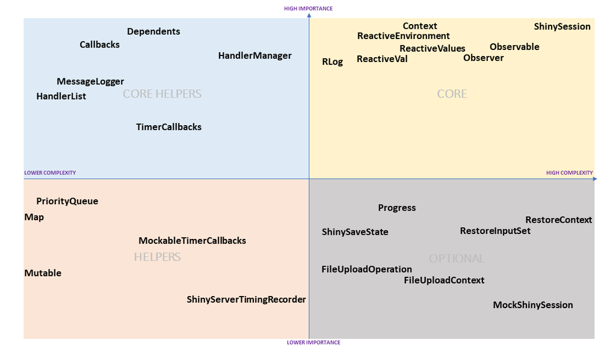

Shiny R6 classes

## When are they created

- **On load**: RLog, TimerCallbacks, HandlerManager
- **In `runApp()`**: ShinySession, Bookmarking classes
- **In the app event loop**: ReactiveEnvironment, Core Helpers
- **User-dependent** (mostly):
  - ReactiveVal (`reactiveVal()`)
  - ReactiveValues (`reactiveValues()`)
  - Observers (`observe()`, `observeEvent()`, `render_X()`)
  - Observable (`reactive()`)

## ShinySession

- You might recognise: `session`
- Contains instances of most helper/core helper classes
- Important tasks
  - Communicates with browser via websockets
  - Handles outputs in the server
  - Initiates and manages ‘cycles’

## ReactiveEnvironment & Context

- ReactiveEnvironment keeps track of Contexts
- Contexts can be **invalidated** (notify the ReactiveEnvironment they need to be ‘flushed’)
- Contexts can be **flushed** (the function is run)

## ReactiveVal & ReactiveValues

- You might recognise: `reactiveVal()` and `reactiveValues()`
- Distinct but similiar
- Keep track of value, label and dependents

## Observer

- You might recognise: `observe()`/`observeEvent()`
- Handling for invalidation (a non-isolated reactive value changes)
- Handling for flushes (app cycle, values have been recalculated)

## Observable

- You might recognise: `reactive()`
- Turns an expression into a function
- Notifies dependents

## What is the point of all this?

- Some common design mistakes
- reactive vs observe
  - i.e. ReactiveVal/ues vs Observable vs Observer
- Overly reactive expressions
  - Understanding the reactive graph
- Misunderstanding modules
  - ShinySession, namespaces and input-output interactions

## To conclude

- Might seem unimportant, hidden for a reason
- Mental models are hard
- Understanding the tools we use is good

## Just for fun

My favourite comments from the {shiny} source code

*(AKA shiny devs are like you and me)*

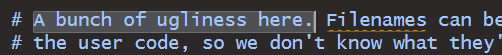

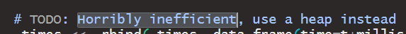

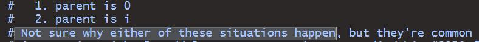

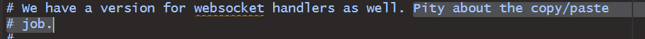

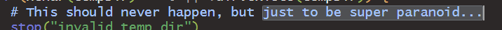

Shiny in Production 2023